# Used Car Price Prediction - Mid Term Summary Paper

## Why Used Car Price Prediction?

A microchip shortage caused by the COVID-19 pandemic has had a significant impact on the global automobile industry, raising used car prices for buyers.

Automobile manufacturers are unable to produce new vehicles due to raw material supply chain issues. Due to a lower-than-usual supply of vehicles on their lots, dealers selling new cars have struggled to keep up with demand. This has an impact on used car dealerships, who are charging higher prices to sell their vehicles. Customers who want to sell their vehicle to a used car dealership, on the other hand, will benefit from higher trade-in values.

Price variations are common and can lead to misleading prices on any other website, necessitating the development of a tool to predict the pricing of used cars based on real data gathered from local websites in order to provide consumers with an accurate evaluation of cars.

When Team Dataverse learned about the recent issue that arose in the automobile industry as a result of the COVID global pandemic, we attempted to determine which car attributes are most important in determining the price of a used car. Our analysis will be accurate enough to assist consumers in determining car pricing for either selling or purchasing purposes based on the vehicle’s features.

## Prior Research and Analysis

With the rise of individual cars, more people are looking into getting their own car at an affordable price, usually looking in the used car market, “For each and every new car sold in the UAE in 2019, about 3.5 used cars were sold” (BIELSKI & RAMARATHNAM, 2020). In the coming years, the industry will be revolutionized, with markets powered by digitalization and new business models to improve focus efficiency and consumer needs.

In recent years, used car prices have risen. Prices increased by 4-10% between 2018 and 2020, but dealers sold more cars in a shorter period of time. Furthermore, analysts have shown that car depreciation costs have only been decreasing in the UAE, a previously unseen phenomenon that has led to an increase in second-hand car demand (Bridge, 2020).

Manheim The used vehicle index has seen an unprecedented increase in used car value, increasing 6.81% in the first 15 days of April 2021 compared to the month of March. In addition, the value has increased by 52.2% since April 2020, with the latest trend indicators indicating a few more weeks of appreciation. This is due to stimulus payments and tax refunds as a result of the Covid-19 ramifications, as well as a global decrease in car production. (2021 Used Vehicle Value Index).

## About the Dataset

The Used-Cars-Catalog data set was obtained from Kaggle (the World’s Largest Data Scientists Community) in order to investigate the used car market. Data is pulled in Belarus (western Europe) on December 2, 2019.

**Dataset Link:** https://www.kaggle.com/datasets/lepchenkov/usedcarscatalog?selectcars.csv=

• The dataset contains 38531 observations.

• The dataset contains 30 variables.

**Dataset Variables:**

• [1-5] Manufacturer Name, Model Name, Transmission, Color, Odometer Value

• [6-10] Year Produced, Engine Fuel, Engine Has Gas, Engine Type, Engine Capacity

• [11-15] Body Type, Warranty, State, Drivetrain, Price in USD

• [16-20] Is Exchangeable, Location, Number of Photos, Upgrade Count, Duration Listed

• [21-30] Feature 0 to Feature 9

• Our team used exploratory data analysis and hypothesis testing to estimate the relationship between the dependent variable (Car’s price), and several independent variables that included both numerical and categorical values.

## Limitations of Dataset

• We have the data only till 2019. So, we don’t know the post covid trends and the changes in the prices couldn’t be explained.

• The dataset has data only related to the Belarus region. There is no global exposure.

• More data can lead to predictions that are more reliable.

• Second, there might be additional traits that are reliable predictors.

• Here are some examples of variables that could enhance the model: doors, gas mileage (mpg), time spent undergoing mechanical and cosmetic repairs, used-to-new ratio, and appraisal-to-trade ratio.

• There are ten unknown features (0-9) in the dataset. We don’t know which part of the car these unknown features represent. Based on the results, we can conclude whether the feature is outdated or a luxury car feature.

## SMART Questions

**Why team came up with the below smart Questions?**

Data Verse team members are avid vehicle enthusiasts, therefore we used their knowledge of the most prevalent and crucial aspects to come up with SMART questions. In order to arrive at a conclusion on the target variable price, a few questions were posed, and analysis was conducted utilizing Boxplots, Scatterplots, t-tests, anova, and chi-square tests, among other tools.

**What are the factors affecting the prices of used cars?**

1. Is the warranty impacting the resale value of the cars?
2. Does the odometer value have any impact on the car prices?
3. Are the car prices dependent on the manufacturer or year of production?
4. Does colour and body type have any impact on the resale prices of the cars?
5. Does the number of photos have any impact on the car’s resale value?
6. Does drivetrain have any impact on the car’s resale value?
7. Are the resale prices of the cars dependent on fuel and engine type?
8. Are the prices of the cars different based on the transmission type and engine capacity?
9. Does unknown features have any impact on car prices?

## Importing the Libraries and Dataset

We have imported the data from cars.csv file and stored it as car_data dataframe.

```r
car_data = data.frame(read.csv('cars.csv'))
str(car_data)
```

```
'data.frame':   38531 obs. of  30 variables:
 $ manufacturer_name: chr  "Subaru" "Subaru" "Subaru" "Subaru" ...
 $ model_name       : chr  "Outback" "Outback" "Forester" "Impreza" ...
 $ transmission     : chr  "automatic" "automatic" "automatic" "mechanical" ...
 $ color            : chr  "silver" "blue" "red" "blue" ...
 $ odometer_value   : int  190000 290000 402000 10000 280000 132449 318280 350000 179000 571317 ...
 $ year_produced    : int  2010 2002 2001 1999 2001 2011 1998 2004 2010 1999 ...
 $ engine_fuel      : chr  "gasoline" "gasoline" "gasoline" "gasoline" ...
 $ engine_has_gas   : chr  "False" "False" "False" "False" ...
 $ engine_type      : chr  "gasoline" "gasoline" "gasoline" "gasoline" ...
 $ engine_capacity  : num  2.5 3 2.5 3 2.5 2.5 2.5 2.5 2.5 2.5 ...
 $ body_type        : chr  "universal" "universal" "suv" "sedan" ...
 $ has_warranty     : chr  "False" "False" "False" "False" ...
 $ state            : chr  "owned" "owned" "owned" "owned" ...
 $ drivetrain       : chr  "all" "all" "all" "all" ...
```

[output cut: 16 more lines]

## Data cleaning

Convert the below variables in the dataset as factor to make them categorical.

• transmission

• engine_fuel

• engine_has_gas

• engine_type

• body_type

• has_warranty

• state

• drivetrain

• is exchangeable

```r
car_data$transmission = as.factor(car_data$transmission)
car_data$engine_fuel = as.factor(car_data$engine_fuel)
car_data$engine_has_gas = as.factor(car_data$engine_has_gas)
car_data$engine_type = as.factor(car_data$engine_type)
car_data$body_type = as.factor(car_data$body_type)
car_data$has_warranty = as.factor(car_data$has_warranty)
car_data$state = as.factor(car_data$state)
car_data$drivetrain = as.factor(car_data$drivetrain)
car_data$is_exchangeable = as.factor(car_data$is_exchangeable)
car_data$location_region = as.factor(car_data$location_region)
```

Updating the unknown features (Feature 0 to Feature 9) as factor in bulk

```r
feature_cols <- c(20:29)
car_data[feature_cols] <- lapply(car_data[feature_cols],factor)
str(car_data)
```

```
'data.frame':   38531 obs. of  30 variables:
 $ manufacturer_name: chr  "Subaru" "Subaru" "Subaru" "Subaru" ...
 $ model_name       : chr  "Outback" "Outback" "Forester" "Impreza" ...
 $ transmission     : Factor w/ 2 levels "automatic","mechanical": 1 1 1 2 1 1 1 1 1 1 ...
 $ color            : chr  "silver" "blue" "red" "blue" ...
 $ odometer_value   : int  190000 290000 402000 10000 280000 132449 318280 350000 179000 571317 ...
 $ year_produced    : int  2010 2002 2001 1999 2001 2011 1998 2004 2010 1999 ...
 $ engine_fuel      : Factor w/ 6 levels "diesel","electric",..: 4 4 4 4 4 4 4 4 4 4 ...
 $ engine_has_gas   : Factor w/ 2 levels "False","True": 1 1 1 1 1 1 1 1 1 1 ...
 $ engine_type      : Factor w/ 3 levels "diesel","electric",..: 3 3 3 3 3 3 3 3 3 3 ...
 $ engine_capacity  : num  2.5 3 2.5 3 2.5 2.5 2.5 2.5 2.5 2.5 ...
 $ body_type        : Factor w/ 12 levels "cabriolet","coupe",..: 11 11 10 9 11 11 11 9 11 11 ...
 $ has_warranty     : Factor w/ 2 levels "False","True": 1 1 1 1 1 1 1 1 1 1 ...
 $ state            : Factor w/ 3 levels "emergency","new",..: 3 3 3 3 3 3 3 3 3 3 ...
 $ drivetrain       : Factor w/ 3 levels "all","front",..: 1 1 1 1 1 1 1 1 1 1 ...
```

[output cut: 16 more lines]

In the dataset, there are 10 null values present in engine_capacity variable.

```r
sapply(car_data, function(x) sum(is.na(x)))
```

```
manufacturer_name        model_name      transmission             color
                0                 0                 0                 0
   odometer_value     year_produced       engine_fuel    engine_has_gas
                0                 0                 0                 0
      engine_type   engine_capacity         body_type      has_warranty
                0                10                 0                 0
            state        drivetrain         price_usd   is_exchangeable
                0                 0                 0                 0
  location_region  number_of_photos        up_counter         feature_0
                0                 0                 0                 0
        feature_1         feature_2         feature_3         feature_4
                0                 0                 0                 0
        feature_5         feature_6         feature_7         feature_8
                0                 0                 0                 0
        feature_9   duration_listed
                0                 0
```

```r
car_data$engine_capacity[is.na(car_data$engine_capacity)] <- 0
getmode <- function(v) {
   uniqv <- unique(v)
   uniqv[which.max(tabulate(match(v, uniqv)))]
}
s <- getmode(car_data$engine_capacity)
cat("For Engine Capcity Mean is:",mean(car_data$engine_capacity),"Median is:",median(car_data$engine_capacity),"Mode is:",s)
```

```
For Engine Capcity Mean is: 2.05 Median is: 2 Mode is: 2
```

```r
car_data$engine_capacity[is.na(car_data$engine_capacity)] <- mean(car_data$engine_capacity,na.rm = TRUE)
sapply(car_data, function(x) sum(is.na(x)))
```

```
manufacturer_name        model_name      transmission             color
                0                 0                 0                 0
   odometer_value     year_produced       engine_fuel    engine_has_gas
                0                 0                 0                 0
      engine_type   engine_capacity         body_type      has_warranty
                0                 0                 0                 0
            state        drivetrain         price_usd   is_exchangeable
                0                 0                 0                 0
  location_region  number_of_photos        up_counter         feature_0
                0                 0                 0                 0
        feature_1         feature_2         feature_3         feature_4
                0                 0                 0                 0
        feature_5         feature_6         feature_7         feature_8
                0                 0                 0                 0
        feature_9   duration_listed
                0                 0
```

• We are not removing the outilers in the odometer variable as some of the vehicles might be in use from longer time.

• The team examined all variables except model_name, engine_has_gas, car_state, Location_region, and Duration List.

## Exploratory Data Analysis

This graph shows about the distribution of Resale prices of the entire dataset.

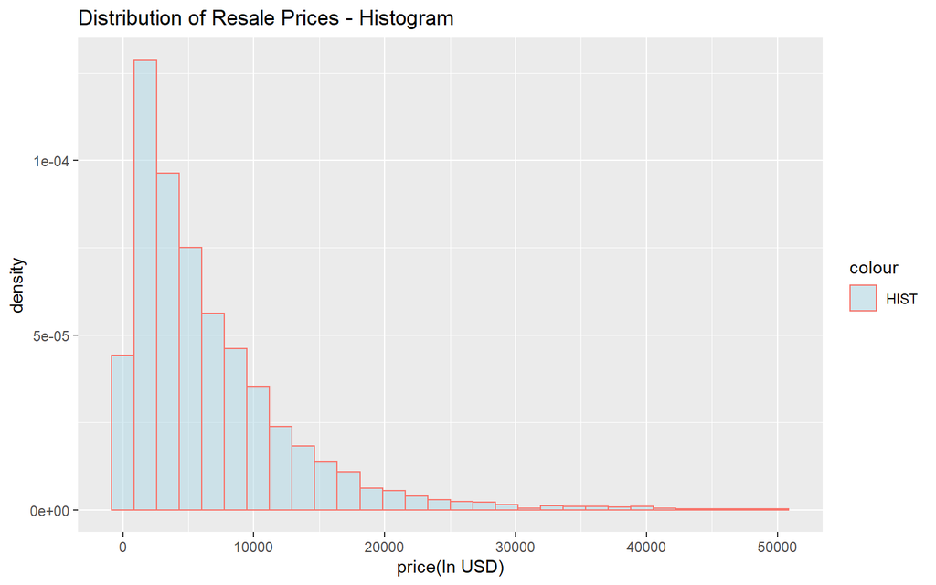

```r
p <- ggplot(car_data, aes(x = price_usd)) +
     geom_histogram(aes(y = stat(density), colour = "HIST"), fill="light blue", bins=30, alpha=.5) +
      labs(x = 'price(In USD)') + labs(title = 'Distribution of Resale Prices - Histogram')
p
```

## Is the warranty impacting the resale value of the cars?

**Boxplot: Price(In USD) vs has_warranty**

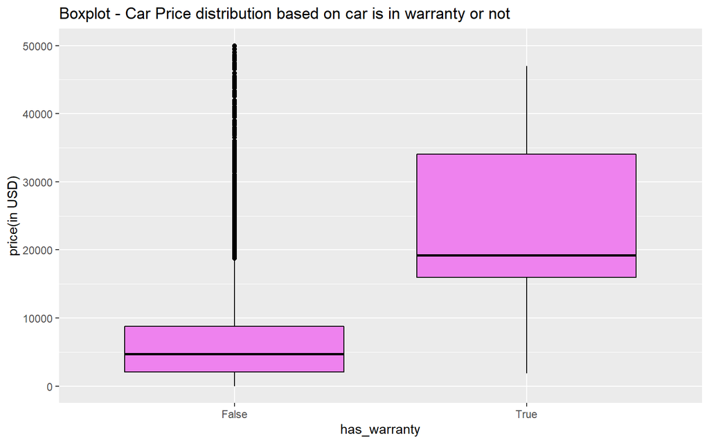

```r
plot_warranty <- ggplot(car_data, aes(x=has_warranty, y=price_usd)) +
geom_boxplot(color="black", fill="violet")+
labs(x="has_warranty",y="price(in USD)") + labs(title="Boxplot - Car Price distribution based on car is in warranty or not")
plot_warranty
```

As we can see, cars which are in warranty have the better resell prices than the cars which are not covered under warranty.

Also we can see so many outliers in ‘no warranty’ categories. That pool is belongs to the vintage cars where prices are high but the car is not in the warranty.

### T-test

```r
with_warranty<-subset(car_data,has_warranty == 'True')
without_warranty<-subset(car_data,has_warranty == 'False')
mean_price = mean(car_data$price_usd)
```

```r
head(car_data)
```

T-test has been performed on has_warranty variable has two sub groups.

H0: Mean price of data is equal to the mean price of two subgroups (With_warranty and Without_warranty)

H1:Mean price of data is not equal to the mean price of two subgroups (With_warranty and Without_warranty)

```r
Hypothesis_test_price_with_warranty = t.test(x=with_warranty$price_usd,mu = mean_price ,conf.level = 0.95)
#default conf.level = 0.95
Hypothesis_test_price_with_warranty
```

```
    One Sample t-test

data:  with_warranty$price_usd
t = 37, df = 448, p-value <2e-16
alternative hypothesis: true mean is not equal to 6640
95 percent confidence interval:
 22635 24452
sample estimates:
mean of x
    23543
```

```r
Hypothesis_test_price_without_warranty = t.test(x=without_warranty$price_usd,mu = mean_price ,conf.level = 0.95)
#default conf.level = 0.95
Hypothesis_test_price_without_warranty
```

```
    One Sample t-test

data:  without_warranty$price_usd
t = -6, df = 38081, p-value = 2e-10
alternative hypothesis: true mean is not equal to 6640
95 percent confidence interval:
 6379 6502
sample estimates:
mean of x
     6441
```

The mean value of two sub categories has significant difference. Hence we are accepting alternate hypothesis.

## Does the odometer value have any impact on the car prices?

**Line Graph: Price(In USD) vs Odometer Value**

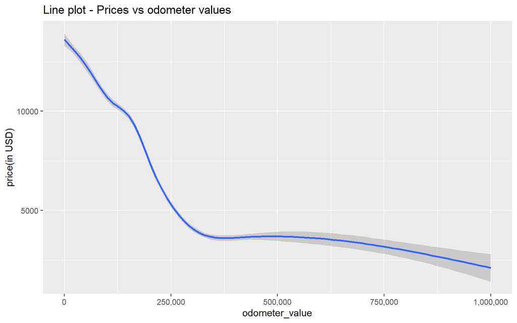

```r
ggplot(data = car_data) +
    geom_smooth(mapping = aes(x = odometer_value, y = price_usd)) +
    scale_x_continuous(name="odometer_value", labels = scales::comma) +
        labs(x = 'odometer_value', y = 'price(in USD)') + labs(title = 'Line plot - Prices vs odometer values')
```

We can clearly see that as odometer value is increasing, car prices are going down.

**Violin Plot: Price(In USD) vs Odometer Value**

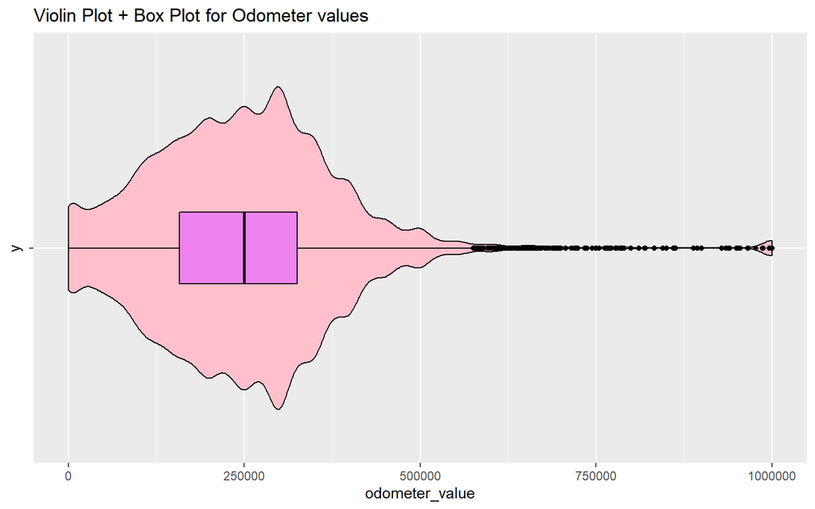

```r
plot3 <- ggplot(car_data,aes(x = odometer_value,y = '',color = odometer_value)) +
        geom_violin(color="black", fill="pink") + geom_boxplot(width = .2,color="black", fill="violet") +
        labs(x = 'odometer_value') + labs(title = 'Violin Plot + Box Plot for Odometer values')
plot3
```

Violin plot, checking odometer distribution and box plot in the same graph.

**Scatter plot with fitting line**

```r
updated_data = outlierKD2(car_data, odometer_value, TRUE, TRUE, TRUE, TRUE)
```

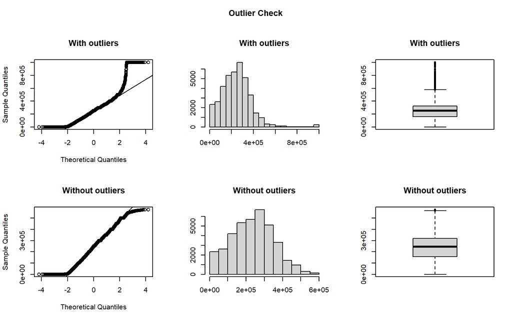

```
Outliers identified: 564
Proportion (%) of outliers: 1.5
Mean of the outliers: 802149
Mean without removing outliers: 248865
Mean if we remove outliers: 240646
Outliers successfully removed
```

**Scatter Plot: Price(In USD) vs Odometer Value**

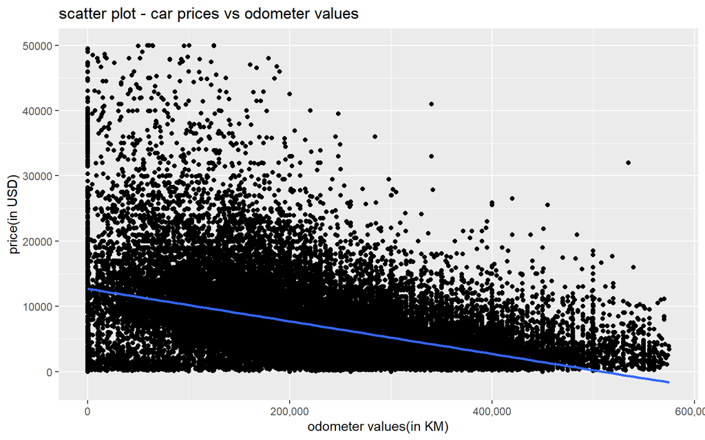

```r
ggplot(updated_data, aes(x=odometer_value, y=price_usd)) +
   geom_point()+
   geom_smooth(method=lm) +
   labs(title = 'scatter plot - car prices vs odometer values') +
   labs(x = 'odometer values(in KM)', y = 'price(in USD)') + scale_x_continuous(name='odometer values(in KM)', labels = scales::comma)
```

By removing outliers from odometer value, we are getting good relation for price vs odometer value.

### Correlation Plot

Correlation plot between the numerical features is considered

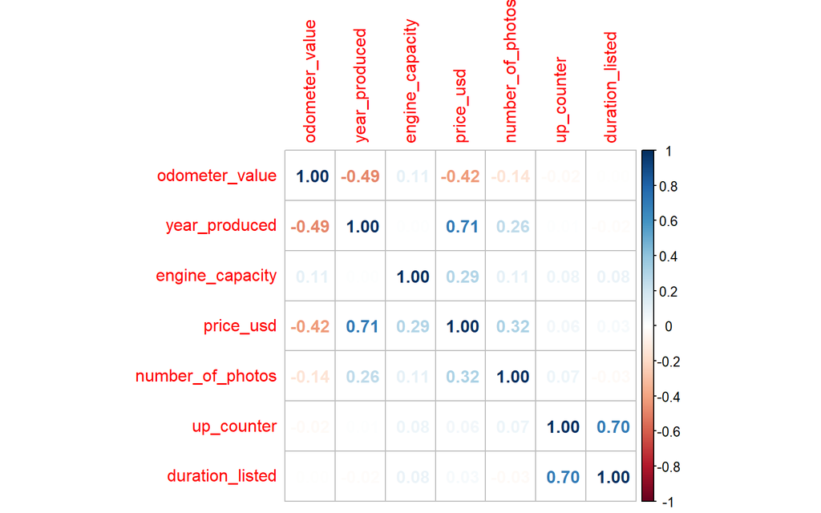

```r
corrplot(cor(cars_numerical), method = 'number')
```

The above correlation plot shows the relation between all the numerical features and the price_usd.

Here, odometer_value has negative correlation with price(cc=-0.42).

## Are the car prices dependent on the manufacturer or year of production?

**Based on Manufacturer**

Top 10 Brands and their Median price in USD.

```r
df_new <- aggregate( price_usd ~ manufacturer_name, car_data, median )
top_10_costy_brands <- df_new[df_new$price_usd %in% tail(sort(df_new$price_usd),10),]
top_10_costy_brands
```

```
   manufacturer_name price_usd
1              Acura     12024
5              Buick     12300
6           Cadillac      9100
20          Infiniti     12000
22            Jaguar     13400
27        Land Rover     12200
28             Lexus     14200
33              Mini     11975
39           Porsche     15000
44             Skoda     10900
```

```r
top_10_manufactuerer_avg_price=subset(car_data,manufacturer_name=='Acura'|manufacturer_name=="Buick"|manufacturer_name=="cadillac"|manufacturer_name=="Infiniti"|manufacturer_name=="Jaguar"|manufacturer_name=="Land Rover"| manufacturer_name=='Lexus'| manufacturer_name=="Mini"|manufacturer_name=="Porsche"|manufacturer_name=="Skoda")
```

**Boxplot - Price(In USD) vs Manufacturer**

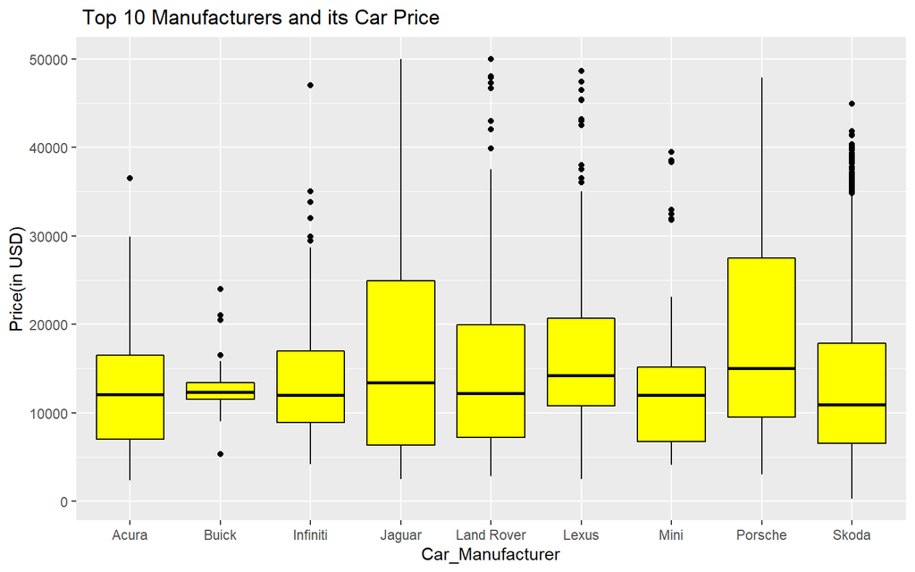

```r
plot_body <- ggplot(top_10_manufactuerer_avg_price, aes(x=manufacturer_name, y=price_usd)) +
  geom_boxplot(color="black", fill="Yellow")+
  labs(x="Car_Manufacturer",y="Price(in USD)") + labs(title=" Top 10 Manufacturers and its Car Price")
plot_body
```

### ANOVA Test

In this ANOVA test, we are checking that is there any significant difference in the mean price on the basis of car manufacturer.

H0: there is no difference in the mean prices of the cars based on manufacturer

H1: there is a difference in the mean prices of the cars based on manufacturer

```r
price_aov<-aov(price_usd ~ manufacturer_name, data=car_data)
price_aov
```

```
Call:
   aov(formula = price_usd ~ manufacturer_name, data = car_data)

Terms:
                manufacturer_name Residuals
Sum of Squares           2.94e+11  1.30e+12
Deg. of Freedom                54     38476

Residual standard error: 5807
Estimated effects may be unbalanced
```

```r
xkabledply(price_aov, title = 'Anova test result impact of manufacturer_name on car price')
```

Anova test result impact of manufacturer_name on car price

|  | Df | Sum Sq | Mean Sq | F value | Pr(>F) |
| --- | --- | --- | --- | --- | --- |
| manufacturer_name | 54 | 2.94e+11 | 5.45e+09 | 162 | 0 |
| Residuals | 38476 | 1.30e+12 | 3.37e+07 | NA | NA |

If p≤α, reject H0; otherwise, do not reject H0.

As we got p value less than α hence we reject the null hypothesis.

It means there is a significant difference in the mean price based on manufacturer.

**Based on year of Production**

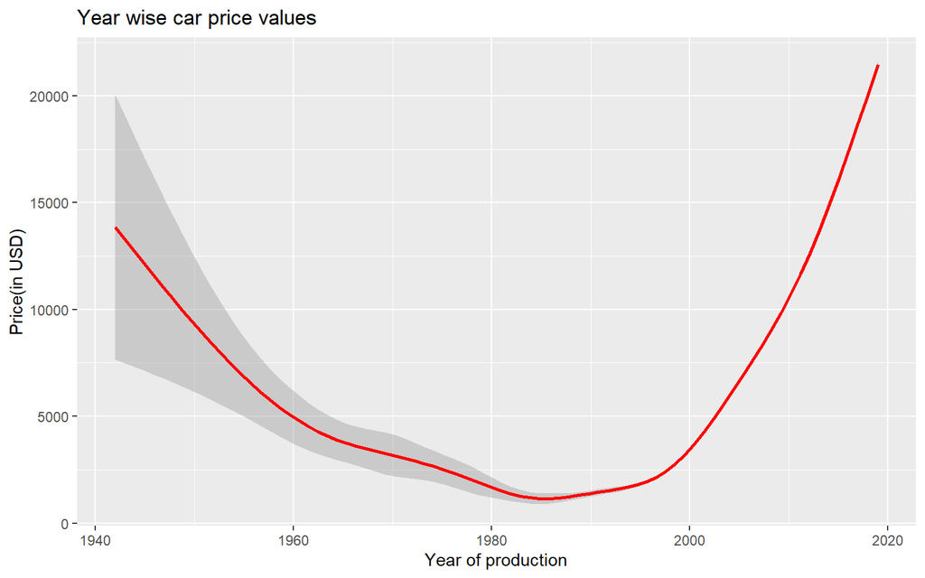

```r
ggplot(data = car_data) +
    geom_smooth(color = 'red',mapping = aes(x = year_produced, y = price_usd)) + labs(x = 'Year of production', y = 'Price(in USD)') +
    labs(title ='Year wise car price values')
```

As we can see that car prices of vintage cars is high. Also the resell price is high for latest cars.

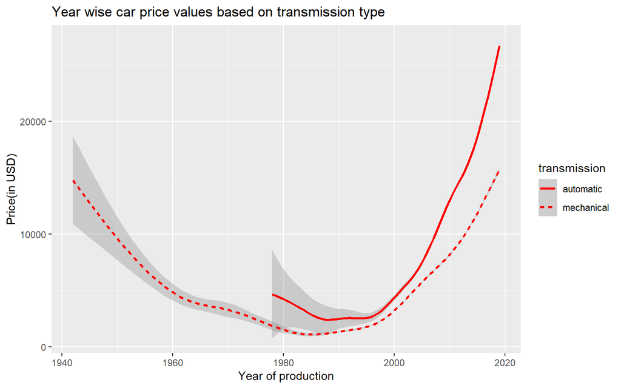

```r
plot_transmission <- ggplot(data = car_data) +
    geom_smooth(color = 'red',mapping = aes(x = year_produced, y = price_usd,linetype = transmission)) +
    labs(title = 'Year wise car price values based on transmission type') + labs(x = 'Year of production', y = 'Price(in USD)')
plot_transmission
```

To check the Vintage category, mechanical are categorize as vintage and automatic cars are available from 1978. We are getting the similar results compared to the previous plot based on complete data.

### Chi Square Test

With the chi square test of independence, we are checking that resale car prices are dependent on the year of manufacture or not.

H0: Car prices and year of production are independent of each other.

H1: Car prices and year of production are dependent of each other.

```r
p_usd.intrv = cut(car_data$price_usd, c(0,10000,20000,30000,40000,50000))
year.intrv = cut(car_data$year_produced, c(1940,1950,1960,1970,1980,1990,2000,2010,2020))
lists <- list(price_intvl = as.character(p_usd.intrv),yr_interval = as.character(year.intrv))
df <- as.data.frame(do.call(cbind, lists))
conTable = table(df)
print(conTable)
```

```
               yr_interval
price_intvl     (1.94e+03,1.95e+03] (1.95e+03,1.96e+03] (1.96e+03,1.97e+03]
  (0,1e+04]                       1                  19                  48
  (1e+04,2e+04]                   0                   1                   4
  (2e+04,3e+04]                   1                   1                   1
  (3e+04,4e+04]                   0                   0                   0
  (4e+04,5e+04]                   0                   0                   0
               yr_interval
price_intvl     (1.97e+03,1.98e+03] (1.98e+03,1.99e+03] (1.99e+03,2e+03]
  (0,1e+04]                     129                2011            13078
  (1e+04,2e+04]                   2                   7               50
  (2e+04,3e+04]                   1                   1                2
  (3e+04,4e+04]                   0                   0                0
  (4e+04,5e+04]                   0                   0                0
               yr_interval
price_intvl     (2.01e+03,2.02e+03] (2e+03,2.01e+03]
  (0,1e+04]                    2148            13307
  (1e+04,2e+04]                3743             2446
  (2e+04,3e+04]                 895              169
  (3e+04,4e+04]                 330               15
  (4e+04,5e+04]                 120                1
```

```r
head(df,3)
```

```
    price_intvl      yr_interval
1 (1e+04,2e+04] (2e+03,2.01e+03]
2     (0,1e+04] (2e+03,2.01e+03]
3     (0,1e+04] (2e+03,2.01e+03]
```

```r
chitest = chisq.test(conTable)
chitest
```

```
    Pearson's Chi-squared test

data:  conTable
X-squared = 15898, df = 28, p-value <2e-16
```

If p≤α, reject H0; otherwise, do not reject H0.

As we got p value less than 0.05 hance we are rejecting the null hypothesis.

It means prices and year of production are dependent of each other

## Does colour and body type have any impact on the resale prices of the cars?

**Boxplot - Price(In USD) vs Car color**

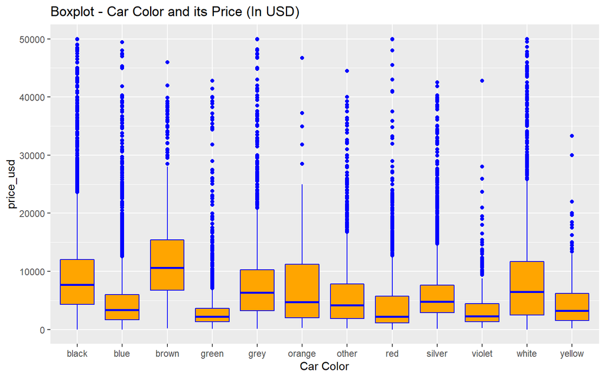

```r
plot1 <- ggplot(car_data, aes(x=color, y=price_usd)) +
  geom_boxplot(color="blue", fill="orange")+
  labs(x="Car Color",y="price_usd") + labs(title="Boxplot - Car Color and its Price (In USD)")
plot1
```

### ANOVA Test

ANOVA is helpful for testing three or more variables.It is similar to multiple two-sample t-tests.The one-way ANOVA is used to determine whether there are any statistically significant differences between the means of three or more independent (unrelated) groups.

The null hypothesis states that the mean resale price in usd is equal among all color groups.

H0 : There is no difference in mean Prices based on color feature

H1 : There is difference in mean Prices based on color feature

Anova test for car color

```r
df_aov_1 = aov(price_usd ~  color , car_data)
summary(df_aov_1)
```

```
               Df   Sum Sq  Mean Sq F value Pr(>F)
color          11 1.70e+11 1.55e+10     420 <2e-16 ***
Residuals   38519 1.42e+12 3.69e+07
---
Signif. codes:  0 '***' 0.001 '**' 0.01 '*' 0.05 '.' 0.1 ' ' 1
```

If p≤α, reject H0; otherwise, do not reject H0.

The p-value is less than the specified significance level of 0.05; we reject H0. The test results are statistically significant at the 5% level and provide very strong evidence against the null hypothesis.

Conclusion:

At 5% significance level, the data provides very strong evidence to conclude that at least one pair of group means of color is different from each other.

**Based on Body Type**

**Boxplot - Price(In USD) vs Body Type**

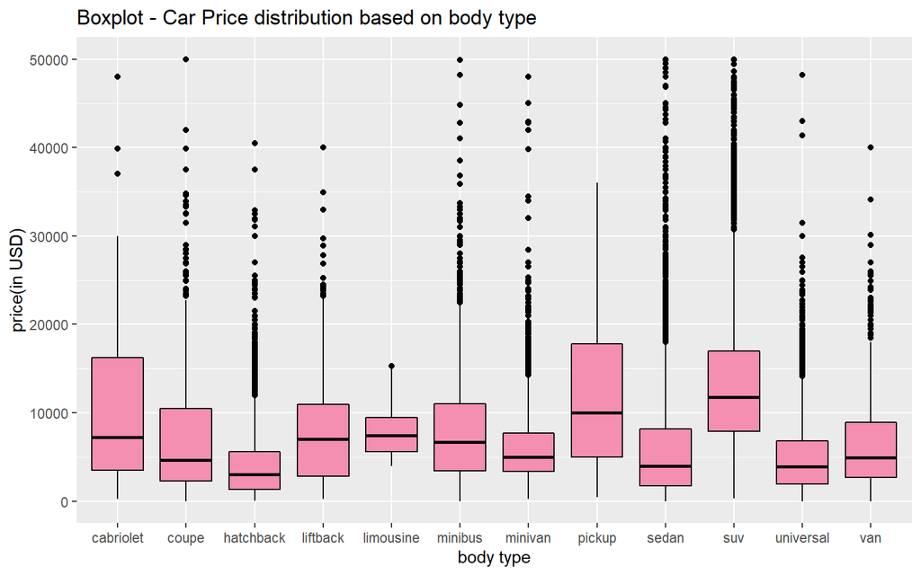

```r
plot_body <- ggplot(car_data, aes(x=body_type, y=price_usd)) +
  geom_boxplot(color="black", fill="#F48FB1")+
  labs(x="body type",y="price(in USD)") + labs(title="Boxplot - Car Price distribution based on body type")
plot_body
```

### ANOVA Test

The null hypothesis states that the mean resale price in usd is equal among all groups of car body type.

H0 : all means are equal

H1 : not all means are equal

Decide on the significance level significance level is α=0.05

```r
df_aov_4 = aov(price_usd ~  body_type , car_data)
summary(df_aov_4)
```

```
               Df   Sum Sq  Mean Sq F value Pr(>F)
body_type      11 3.50e+11 3.18e+10     986 <2e-16 ***
Residuals   38519 1.24e+12 3.23e+07
---
Signif. codes:  0 '***' 0.001 '**' 0.01 '*' 0.05 '.' 0.1 ' ' 1
```

If p≤α, reject H0; otherwise, do not reject H0.

The p-value is less than the specified significance level of 0.05; we reject null hypothesis. The test results are statistically significant at the 5% level and provide very strong evidence against the null hypothesis.

Conclusion:

At 5% significance level, the data provides very strong evidence to conclude that at least one pair of group means of body type is different from each other.

## Does the number of photos have any impact on the car’s resale value?

Creating buckets for number of photos feature

```r
Photo_bucket <- within(car_data, {
  Photo_bucket.cat <- NA # need to initialize variable
  Photo_bucket.cat[number_of_photos < 6] <- "0-5"
  Photo_bucket.cat[number_of_photos >= 6 & number_of_photos < 11] <- "6-10"
  Photo_bucket.cat[number_of_photos >= 11 & number_of_photos < 16] <- "11-15"
  Photo_bucket.cat[number_of_photos >= 16 & number_of_photos < 21] <- "16-20"
  Photo_bucket.cat[number_of_photos >= 21 & number_of_photos < 26] <- "21-25"
  Photo_bucket.cat[number_of_photos >= 26 & number_of_photos < 31] <- "26-30"
  Photo_bucket.cat[number_of_photos > 30] <- "more than 30"
   } )

Photo_bucket$Photo_bucket.cat <- factor(Photo_bucket$Photo_bucket.cat, levels= c("0-5","6-10","11-15","16-20","21-25","26-30","more than 30"))
```

**Boxplot - Price(In USD) vs Number of Photos**

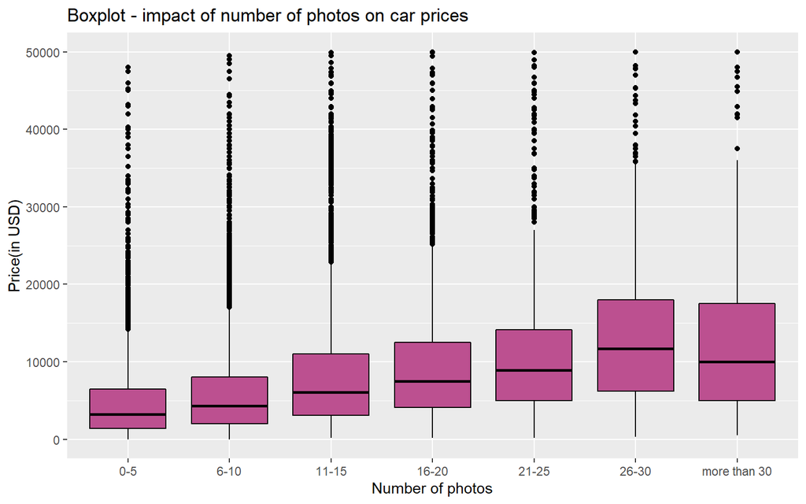

```r
ggplot(Photo_bucket, aes(y = price_usd , x = Photo_bucket.cat)) + geom_boxplot(color="black", fill="#bc5090") + labs(title = 'Boxplot - impact of number of photos on car prices') + labs(x = 'Number of photos', y = 'Price(in USD)')
```

## Does drivetrain have any impact on the car’s resale value?

**Boxplot - Price(In USD) vs Drivetrain**

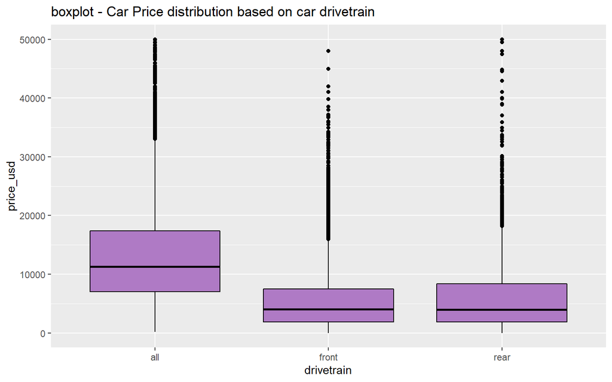

```r
plot_warranty <- ggplot(car_data, aes(x=drivetrain, y=price_usd)) +
  geom_boxplot(color="black", fill="#AF7AC5")+
  labs(x="drivetrain",y="price_usd") + labs(title="boxplot - Car Price distribution based on car drivetrain")
plot_warranty
```

### ANOVA Test

H0: No difference in the mean price based on drivetrain.

H1: There is a difference in the mean price based on drivetrain.

```r
cartrain_aov<-aov(price_usd ~ drivetrain, data=car_data)
cartrain_aov
```

```
Call:
   aov(formula = price_usd ~ drivetrain, data = car_data)

Terms:
                drivetrain Residuals
Sum of Squares    3.10e+11  1.28e+12
Deg. of Freedom          2     38528

Residual standard error: 5769
Estimated effects may be unbalanced
```

```r
xkabledply(cartrain_aov, title = 'Anova test result impact of drivetrain on car prices')
```

Anova test result impact of drivetrain on car prices

|  | Df | Sum Sq | Mean Sq | F value | Pr(>F) |
| --- | --- | --- | --- | --- | --- |
| drivetrain | 2 | 3.10e+11 | 1.55e+11 | 4658 | 0 |
| Residuals | 38528 | 1.28e+12 | 3.33e+07 | NA | NA |

The p-value is less than the specified significance level of 0.05; we reject null hypothesis. The test results are statistically significant at the 5% level and provide very strong evidence against the null hypothesis.

## Are the resale prices of the cars dependent on fuel and engine type?

**Based on Engine Fuel**

**Boxplot- Price(In USD) vs Engine fuel**

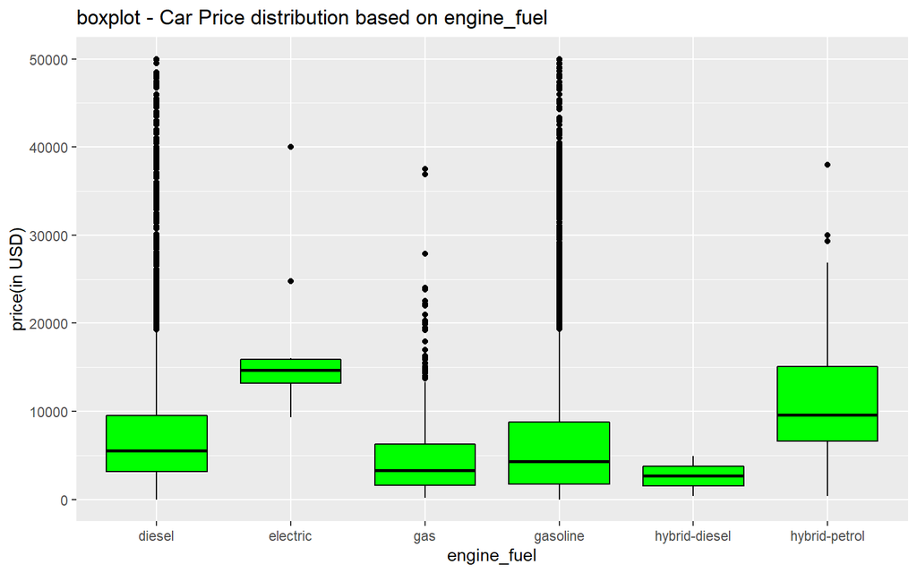

```r
plot1 <- ggplot(car_data, aes(x=engine_fuel, y=price_usd)) +
  geom_boxplot(color="black", fill="green")+
  labs(x="engine_fuel",y="price(in USD)") + labs(title="boxplot - Car Price distribution based on engine_fuel")
plot1
```

### ANOVA Test

The null hypothesis states that the mean resale price in usd is equal among all groups of engine fuel types.

Null Hypothesis H0 : μ1=μ2=μ3=μ4=μ5=μ6

Alternate Hypothesis H1 : not all means are equal

Decide on the significance level significance level is alpha=0.05

```r
df_aov_2 = aov(price_usd~  engine_fuel , car_data)
summary(df_aov_2)
```

```
               Df   Sum Sq  Mean Sq F value Pr(>F)
engine_fuel     5 2.27e+10 4.54e+09     111 <2e-16 ***
Residuals   38525 1.57e+12 4.07e+07
---
Signif. codes:  0 '***' 0.001 '**' 0.01 '*' 0.05 '.' 0.1 ' ' 1
```

If p≤α, reject H0; otherwise, do not reject H0. The p-value is less than the specified significance level of 0.05; we reject H0. The test results are statistically significant at the 5% level and provide very strong evidence against the null hypothesis.

Conclusion: Again, we may conclude that at the 5% significance level, the data provides very strong evidence to conclude that at least one pair of group means of engine fuel type is different from each other.

**Based on Engine Type**

*Density plot _ Price(In USD) vs Engine Type**

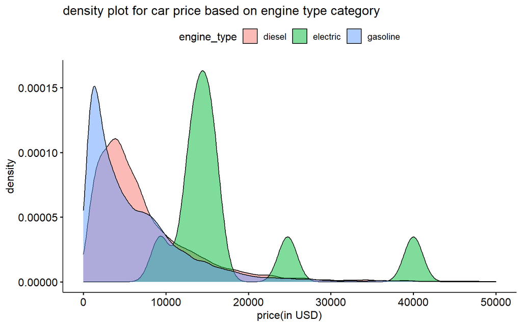

```r
library(ggpubr)
xplot <- ggdensity(car_data, "price_usd", fill = "engine_type",
                   palette = "arc") + labs(title = 'density plot for car price based on engine type category') + labs(x = 'price(in USD)')
xplot
```

We can clearly separate out electric engine category from diesel and gasoline. most of the distribution is overlapped for diesel and gasoline and we can see the Pareto distribution in both the categories.

### ANOVA TEST

Setting the Hypothesis The null hypothesis states that the mean resale price in usd is equal among all groups of engine types.

Null Hypothesis H0 : μ1=μ2=μ3

Alternate Hypothesis H1 : not all means are equal

Decide on the significance level Significance level is alpha=0.05

```r
df_aov_3 = aov(price_usd~  engine_type , car_data)
summary(df_aov_3)
```

```
               Df   Sum Sq  Mean Sq F value Pr(>F)
engine_type     2 1.28e+10 6.38e+09     156 <2e-16 ***
Residuals   38528 1.58e+12 4.10e+07
---
Signif. codes:  0 '***' 0.001 '**' 0.01 '*' 0.05 '.' 0.1 ' ' 1
```

If p≤α, reject H0; otherwise, do not reject H0. The p-value is less than the specified significance level of 0.05; we reject H0. The test results are statistically significant at the 5% level and provide very strong evidence against the null hypothesis.

Conclusion from anova test: Again, we may conclude that at the 5% significance level, the data provides very strong evidence to conclude that at least one pair of group means of engine type is different from each other.

## Are the prices of the cars different based on the transmission type and engine capacity?

**Based on Transmission Type**

**Boxplot - Price(In USD) vs Transmission Type**

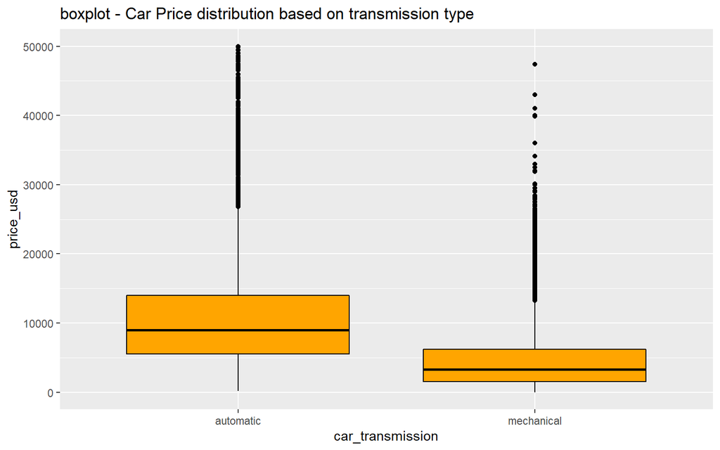

```r
plot1 <- ggplot(car_data, aes(x=transmission, y=price_usd)) +
  geom_boxplot(color="black", fill="orange")+
  labs(x="car_transmission",y="price_usd") + labs(title="boxplot - Car Price distribution based on transmission type")
plot1
```

**Based on Engine Capacity**

**Line Graph - Price(In USD) vs Engine Capacity**

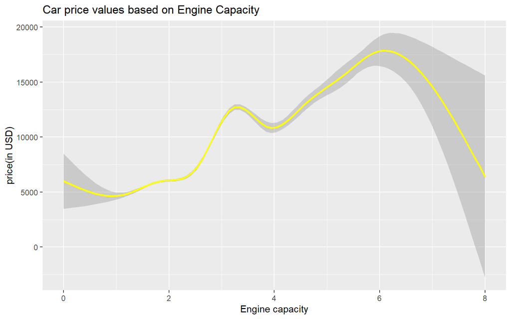

```r
ggplot(data = car_data, aes(x = engine_capacity, y = price_usd)) +
    geom_smooth(color = 'yellow') +
    labs(title = 'Car price values based on Engine Capacity') + labs(x = 'Engine capacity', y = 'price(in USD)')
```

## Does unknown features have any impact on car prices?

Unknown features(feature0 to feature9)

### T-test on Feature 0

Is feature_0 impacting the average car price?

```r
with_feature_0<-subset(car_data,feature_0 == 'True')
without_feature_0<-subset(car_data,feature_0 == 'False')
```

```r
head(car_data,3)
```

```
  manufacturer_name model_name transmission  color odometer_value year_produced
1            Subaru    Outback    automatic silver         190000          2010
2            Subaru    Outback    automatic   blue         290000          2002
3            Subaru   Forester    automatic    red         402000          2001
  engine_fuel engine_has_gas engine_type engine_capacity body_type has_warranty
1    gasoline          False    gasoline             2.5 universal        False
2    gasoline          False    gasoline             3.0 universal        False
3    gasoline          False    gasoline             2.5       suv        False
  state drivetrain price_usd is_exchangeable location_region number_of_photos
1 owned        all     10900           False    Минская обл.                9
2 owned        all      5000            True    Минская обл.               12
3 owned        all      2800            True    Минская обл.                4
  up_counter feature_0 feature_1 feature_2 feature_3 feature_4 feature_5
1         13     False      True      True      True     False      True
2         54     False      True     False     False      True      True
3         72     False      True     False     False     False     False
  feature_6 feature_7 feature_8 feature_9 duration_listed
1     False      True      True      True              16
2     False     False     False      True              83
3     False     False      True      True             151
```

```r
mean_price = mean(car_data$price_usd)
mean_price
```

```
[1] 6640
```

```r
Hypothesis_test_price_with_feature0 = t.test(x=with_feature_0$price_usd,mu = mean_price ,conf.level = 0.95)
#default conf.level = 0.95
Hypothesis_test_price_with_feature0
```

```
    One Sample t-test

data:  with_feature_0$price_usd
t = -40, df = 8805, p-value <2e-16
alternative hypothesis: true mean is not equal to 6640
95 percent confidence interval:
 3867 4125
sample estimates:
mean of x
     3996
```

```r
Hypothesis_test_price_without_feature0 = t.test(x=without_feature_0$price_usd,mu = mean_price ,conf.level = 0.95)
#default conf.level = 0.95
Hypothesis_test_price_without_feature0
```

```
    One Sample t-test

data:  without_feature_0$price_usd
t = 21, df = 29724, p-value <2e-16
alternative hypothesis: true mean is not equal to 6640
95 percent confidence interval:
 7352 7495
sample estimates:
mean of x
     7423
```

We got low price interval if feature0 is in the car. So probably its outdated feature.

### T-test on Feature 1

Is feature_1 impacting the average car price?

```r
with_feature_1<-subset(car_data,feature_1 == 'True')
without_feature_1<-subset(car_data,feature_1 == 'False')
```

```r
mean_price = mean(car_data$price_usd)
mean_price
```

```
[1] 6640
```

```r
Hypothesis_test_price_with_feature1 = t.test(x=with_feature_1$price_usd,mu = mean_price ,conf.level = 0.95)
#default conf.level = 0.95
Hypothesis_test_price_with_feature1
```

```
    One Sample t-test

data:  with_feature_1$price_usd
t = 33, df = 23395, p-value <2e-16
alternative hypothesis: true mean is not equal to 6640
95 percent confidence interval:
 7883 8042
sample estimates:
mean of x
     7963
```

```r
Hypothesis_test_price_without_feature1 = t.test(x=without_feature_1$price_usd,mu = mean_price ,conf.level = 0.95)
#default conf.level = 0.95
Hypothesis_test_price_without_feature1
```

```
    One Sample t-test

data:  without_feature_1$price_usd
t = -40, df = 15134, p-value <2e-16
alternative hypothesis: true mean is not equal to 6640
95 percent confidence interval:
 4496 4695
sample estimates:
mean of x
     4596
```

### T-test on Feature 2

Is feature_2 impacting the average car price?

```r
with_feature_2<-subset(car_data,feature_2 == 'True')
without_feature_2<-subset(car_data,feature_2 == 'False')
```

```r
mean_price = mean(car_data$price_usd)
mean_price
```

```
[1] 6640
```

```r
Hypothesis_test_price_with_feature2 = t.test(x=with_feature_2$price_usd,mu = mean_price ,conf.level = 0.95)
#default conf.level = 0.95
Hypothesis_test_price_with_feature2
```

```
    One Sample t-test

data:  with_feature_2$price_usd
t = 48, df = 8623, p-value <2e-16
alternative hypothesis: true mean is not equal to 6640
95 percent confidence interval:
 10521 10855
sample estimates:
mean of x
    10688
```

```r
Hypothesis_test_price_without_feature2 = t.test(x=without_feature_2$price_usd,mu = mean_price ,conf.level = 0.95)
#default conf.level = 0.95
Hypothesis_test_price_without_feature2
```

```
    One Sample t-test

data:  without_feature_2$price_usd
t = -37, df = 29906, p-value <2e-16
alternative hypothesis: true mean is not equal to 6640
95 percent confidence interval:
 5411 5534
sample estimates:
mean of x
     5473
```

### T-test on Feature 3

Is feature_3 impacting the average car price?

```r
with_feature_3<-subset(car_data,feature_3 == 'True')
without_feature_3<-subset(car_data,feature_3 == 'False')
```

```r
mean_price = mean(car_data$price_usd)
mean_price
```

```
[1] 6640
```

```r
Hypothesis_test_price_with_feature3 = t.test(x=with_feature_3$price_usd,mu = mean_price ,conf.level = 0.95)
#default conf.level = 0.95
Hypothesis_test_price_with_feature3
```

```
    One Sample t-test

data:  with_feature_3$price_usd
t = 69, df = 10626, p-value <2e-16
alternative hypothesis: true mean is not equal to 6640
95 percent confidence interval:
 11405 11685
sample estimates:
mean of x
    11545
```

```r
Hypothesis_test_price_without_feature3 = t.test(x=without_feature_3$price_usd,mu = mean_price ,conf.level = 0.95)
#default conf.level = 0.95
Hypothesis_test_price_without_feature3
```

```
    One Sample t-test

data:  without_feature_3$price_usd
t = -64, df = 27903, p-value <2e-16
alternative hypothesis: true mean is not equal to 6640
95 percent confidence interval:
 4715 4829
sample estimates:
mean of x
     4772
```

### T-test on Feature 4

Is feature_4 impacting the average car price?

```r
with_feature_4<-subset(car_data,feature_4 == 'True')
without_feature_4<-subset(car_data,feature_4 == 'False')
```

```r
mean_price = mean(car_data$price_usd)
mean_price
```

```
[1] 6640
```

```r
Hypothesis_test_price_with_feature4 = t.test(x=with_feature_4$price_usd,mu = mean_price ,conf.level = 0.95)
#default conf.level = 0.95
Hypothesis_test_price_with_feature4
```

```
    One Sample t-test

data:  with_feature_4$price_usd
t = 47, df = 9303, p-value <2e-16
alternative hypothesis: true mean is not equal to 6640
95 percent confidence interval:
 10310 10629
sample estimates:
mean of x
    10470
```

```r
Hypothesis_test_price_without_feature4 = t.test(x=without_feature_4$price_usd,mu = mean_price ,conf.level = 0.95)
#default conf.level = 0.95
Hypothesis_test_price_without_feature4
```

```
    One Sample t-test

data:  without_feature_4$price_usd
t = -39, df = 29226, p-value <2e-16
alternative hypothesis: true mean is not equal to 6640
95 percent confidence interval:
 5359 5482
sample estimates:
mean of x
     5421
```

### T-test on Feature 5

Is feature_5 impacting the average car price?

```r
with_feature_5<-subset(car_data,feature_5 == 'True')
without_feature_5<-subset(car_data,feature_5 == 'False')
```

```r
mean_price = mean(car_data$price_usd)
mean_price
```

```
[1] 6640
```

```r
Hypothesis_test_price_with_feature5 = t.test(x=with_feature_5$price_usd,mu = mean_price ,conf.level = 0.95)
#default conf.level = 0.95
Hypothesis_test_price_with_feature5
```

```
    One Sample t-test

data:  with_feature_5$price_usd
t = 62, df = 13719, p-value <2e-16
alternative hypothesis: true mean is not equal to 6640
95 percent confidence interval:
 10277 10514
sample estimates:
mean of x
    10396
```

```r
Hypothesis_test_price_without_feature5 = t.test(x=without_feature_5$price_usd,mu = mean_price ,conf.level = 0.95)
#default conf.level = 0.95
Hypothesis_test_price_without_feature5
```

```
    One Sample t-test

data:  without_feature_5$price_usd
t = -66, df = 24810, p-value <2e-16
alternative hypothesis: true mean is not equal to 6640
95 percent confidence interval:
 4502 4625
sample estimates:
mean of x
     4563
```

### T-test on Feature 6

Is feature_6 impacting the average car price?

```r
with_feature_6<-subset(car_data,feature_6 == 'True')
without_feature_6<-subset(car_data,feature_6 == 'False')
```

```r
mean_price = mean(car_data$price_usd)
mean_price
```

```
[1] 6640
```

```r
Hypothesis_test_price_with_feature6 = t.test(x=with_feature_6$price_usd,mu = mean_price ,conf.level = 0.95)
#default conf.level = 0.95
Hypothesis_test_price_with_feature6
```

```
    One Sample t-test

data:  with_feature_6$price_usd
t = 66, df = 6587, p-value <2e-16
alternative hypothesis: true mean is not equal to 6640
95 percent confidence interval:
 12844 13224
sample estimates:
mean of x
    13034
```

```r
Hypothesis_test_price_without_feature6 = t.test(x=without_feature_6$price_usd,mu = mean_price ,conf.level = 0.95)
#default conf.level = 0.95
Hypothesis_test_price_without_feature6
```

```
    One Sample t-test

data:  without_feature_6$price_usd
t = -45, df = 31942, p-value <2e-16
alternative hypothesis: true mean is not equal to 6640
95 percent confidence interval:
 5264 5378
sample estimates:
mean of x
     5321
```

### T-test on Feature 7

Is feature_7 impacting the average car price?

```r
with_feature_7<-subset(car_data,feature_7 == 'True')
without_feature_7<-subset(car_data,feature_7 == 'False')
```

```r
mean_price = mean(car_data$price_usd)
mean_price
```

```
[1] 6640
```

```r
Hypothesis_test_price_with_feature7 = t.test(x=with_feature_7$price_usd,mu = mean_price ,conf.level = 0.95)
#default conf.level = 0.95
Hypothesis_test_price_with_feature7
```

```
    One Sample t-test

data:  with_feature_7$price_usd
t = 73, df = 10161, p-value <2e-16
alternative hypothesis: true mean is not equal to 6640
95 percent confidence interval:
 11850 12139
sample estimates:
mean of x
    11994
```

```r
Hypothesis_test_price_without_feature7 = t.test(x=without_feature_7$price_usd,mu = mean_price ,conf.level = 0.95)
#default conf.level = 0.95
Hypothesis_test_price_without_feature7
```

```
    One Sample t-test

data:  without_feature_7$price_usd
t = -68, df = 28368, p-value <2e-16
alternative hypothesis: true mean is not equal to 6640
95 percent confidence interval:
 4667 4777
sample estimates:
mean of x
     4722
```

### T-test on Feature 8

Is feature_8 impacting the average car price?

```r
with_feature_8<-subset(car_data,feature_8 == 'True')
without_feature_8<-subset(car_data,feature_8 == 'False')
```

```r
mean_price = mean(car_data$price_usd)
mean_price
```

```
[1] 6640
```

```r
Hypothesis_test_price_with_feature8 = t.test(x=with_feature_8$price_usd,mu = mean_price ,conf.level = 0.95)
#default conf.level = 0.95
Hypothesis_test_price_with_feature8
```

```
    One Sample t-test

data:  with_feature_8$price_usd
t = 63, df = 16002, p-value <2e-16
alternative hypothesis: true mean is not equal to 6640
95 percent confidence interval:
  9959 10172
sample estimates:
mean of x
    10065
```

```r
Hypothesis_test_price_without_feature8 = t.test(x=without_feature_8$price_usd,mu = mean_price ,conf.level = 0.95)
#default conf.level = 0.95
Hypothesis_test_price_without_feature8
```

```
    One Sample t-test

data:  without_feature_8$price_usd
t = -77, df = 22527, p-value <2e-16
alternative hypothesis: true mean is not equal to 6640
95 percent confidence interval:
 4144 4269
sample estimates:
mean of x
     4207
```

### T-test on Feature 9

Is feature_9 impacting the average car price?

```r
with_feature_9<-subset(car_data,feature_9 == 'True')
without_feature_9<-subset(car_data,feature_9 == 'False')
```

```r
mean_price = mean(car_data$price_usd)
mean_price
```

```
[1] 6640
```

```r
Hypothesis_test_price_with_feature9 = t.test(x=with_feature_9$price_usd,mu = mean_price ,conf.level = 0.95)
#default conf.level = 0.95
Hypothesis_test_price_with_feature9
```

```
    One Sample t-test

data:  with_feature_9$price_usd
t = 33, df = 22324, p-value <2e-16
alternative hypothesis: true mean is not equal to 6640
95 percent confidence interval:
 8010 8185
sample estimates:
mean of x
     8098
```

```r
Hypothesis_test_price_without_feature9 = t.test(x=without_feature_9$price_usd,mu = mean_price ,conf.level = 0.95)
#default conf.level = 0.95
Hypothesis_test_price_without_feature9
```

```
    One Sample t-test

data:  without_feature_9$price_usd
t = -47, df = 16205, p-value <2e-16
alternative hypothesis: true mean is not equal to 6640
95 percent confidence interval:
 4548 4716
sample estimates:
mean of x
     4632
```

In this dataset, we have 10 unknown features, and we are not aware that which part of the car these features are representing. So, to test the impact, we designed the t-test for all the features.

H0: There is no difference in the mean price of the cars and the mean price based on unknown features. H1: There is a difference in the mean price of the cars and the mean price based on unknown features.

As we are getting the p-value significantly less and we can clearly see that the mean price is not falling in the price range we got based on the unknown feature category.

## Did SMART Questions changed after EDA?

• Dataset only have data from six locations, the team did not use the Location variable.

• The team decided to include an analysis of unknown features because these features have a significant impact on the car’s price.

## Conclusion

After Performing Exploratory Data Analysis and Hypothesis testing between dependent variable (price) and several independent variables, we have come to the conclusion that the variables warranty, odometer, manufacturer, year of production, color, body type, drivetrain, number of photos, fuel type, engine type, transmission type, engine capacity have an affect on price of the car.

Unknown features have some impact on car prices. We confirmed the same with the T-test and we decided to include some highly correlated features by applying feature engineering techniques.